# CS・顧客満足アンケート分析（サンプル）

takasumi.miyamoto

5/4/2020

## 前準備

### ライブラリ

使用するライブラリのロード。基本はtdyverseで必要な処理に応じてライブラリを追加。

```r
library(tidyverse)
library(scales)
library(caret) # dummyVars ダミー変数生成
library(ggcorrplot) # ggcorrplot 相関行列
# library(corrplot) # cor.plot
# library(psych)
library(knitr) # knitr
library(kableExtra)
```

### データ

#### 1. csv読み込み

対象csvを下記のディレクトリに配置した場合。

```r
setwd("~/Google Drive/Corporate04.PichDeckExpress/workspace/uniqlo/") #wdの指定
ud <- read_csv("usample.csv")
```

#### 2. 列名変更

必ずしも必要ではない。Google Formアンケートでは質問項目の名称がそのまま列名として挿入される。集計時に列名としては冗長となる場合があるため簡素化。

```r
ud <- rename(ud, 時刻 = タイムスタンプ,
             レジ = レジの対応やスピード,
             売り場 = 売り場でのご案内,
             試着室 = 試着室でのご案内,
             裾直し = お裾直しの仕上がり,
             陳列 = 商品の選びやすさ,
             満足度 = 総合満足度)
```

#### 3. factorの順番指定

質的変数/factor の水準/level に対して、順番を明示的に指定。表にした際に並び順がバラバラにならないように。

```r
ud$性別 <- fct_relevel(ud$性別, "女性", "男性")
ud$来店曜日 <- fct_relevel(ud$来店曜日, "月曜日", "火曜日", "水曜日", "木曜日", "金曜日", "土曜日", "日曜日")
ud$年齢 <- fct_relevel(ud$年齢, "20歳以下", "20代", "30代", "40代", "50代", "60歳以上")
ud$来店時間 <- fct_relevel(ud$来店時間, "7am - 9 am", "10am - 12am", "13 pm - 15pm", "16pm - 18pm", "19pm - 21pm")
ud$来店店舗 <- fct_relevel(ud$来店店舗, "店舗A", "店舗B", "店舗C", "店舗D", "店舗E")
```

*参照 R Graphics Cookbook https://r-graphics.org/recipe-dataprep-factor-reorder

## 1.「満足度」単純集計

目的変数である「満足度」の単純集計。

### 満足度

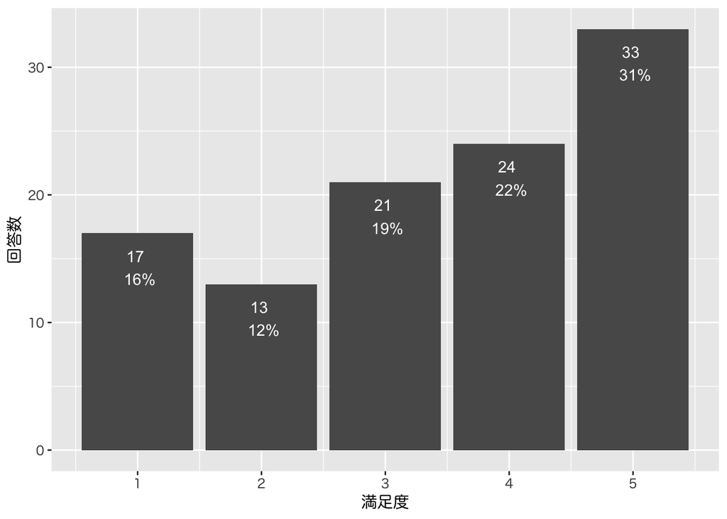

```r
ud %>% count(満足度) %>% mutate(pct = percent( n / sum(n) %>% round(2), 1)) %>%
  ggplot(aes(満足度, n)) + geom_col() +
  geom_text(aes(label = paste(n, "\n", pct)), color = "white", vjust = 1.5) +
  ylab("回答数")
```

```r
ud %>% count(満足度) %>% mutate(pct = percent( n / sum(n) %>% round(2), 1)) %>%  kable() %>% kable_styling(full_width = F, position = "left")
```

| 満足度 | n | pct |
| --- | --- | --- |
| 1 | 17 | 16% |
| 2 | 13 | 12% |
| 3 | 21 | 19% |
| 4 | 24 | 22% |
| 5 | 33 | 31% |

## 相関係数

### 項目同士で相関が認められるものを表示

### データ

#### 1. ダミー変数生成

対象となる変数を指定、質的変数/カテゴリカルデータを抽出してダミー変数（0,1）に置き換え。

```r
ud_dumm <- dummyVars(~., data = ud[2:12]) #2行目以降をダミー変数化
ud_dumm <- as.data.frame(predict(ud_dumm, ud))
```

#### 2. 相関行列

相関行列表。scaleで正規化してcorで相関行列を生成、小数点以下をroundして表示。

```r
ud_dumm %>% scale() %>% cor() %>% round(1) #表
```

```
##                       性別.女性 性別.男性 年齢.20歳以下 年齢.20代 年齢.30代
## 性別.女性                   1.0      -1.0           0.1       0.1      -0.1
## 性別.男性                  -1.0       1.0          -0.1      -0.1       0.1
## 年齢.20歳以下               0.1      -0.1           1.0      -0.3      -0.2
## 年齢.20代                   0.1      -0.1          -0.3       1.0      -0.3
## 年齢.30代                  -0.1       0.1          -0.2      -0.3       1.0
## 年齢.40代                  -0.1       0.1          -0.2      -0.3      -0.2
## 年齢.50代                   0.0       0.0          -0.2      -0.2      -0.2
## 年齢.60歳以上               0.0       0.0          -0.1      -0.2      -0.1
## 来店曜日.月曜日            -0.2       0.2           0.1       0.1       0.1
## 来店曜日.火曜日             0.2      -0.2          -0.1       0.0      -0.2
## 来店曜日.水曜日             0.1      -0.1           0.0       0.1      -0.1
## 来店曜日.木曜日            -0.1       0.1          -0.1      -0.1       0.3
## 来店曜日.金曜日             0.1      -0.1           0.0       0.0       0.1
## 来店曜日.土曜日             0.0       0.0           0.0      -0.1      -0.1
## 来店曜日.日曜日            -0.1       0.1           0.1       0.0      -0.1
## 来店時間.7am - 9 am         0.0       0.0          -0.1       0.0      -0.1
## 来店時間.10am - 12am        0.0       0.0           0.0       0.0       0.1
## 来店時間.13 pm - 15pm       0.0       0.0          -0.1      -0.1       0.1
## 来店時間.16pm - 18pm       -0.1       0.1           0.0       0.1      -0.1
## 来店時間.19pm - 21pm        0.0       0.0           0.2       0.0      -0.1
## 来店店舗.店舗A              0.2      -0.2           0.1       0.1       0.1
## 来店店舗.店舗B             -0.1       0.1          -0.1      -0.2       0.0
## 来店店舗.店舗C             -0.2       0.2          -0.1       0.1       0.1
## 来店店舗.店舗D              0.0       0.0           0.0      -0.2       0.0
## 来店店舗.店舗E              0.0       0.0           0.1       0.2      -0.2
## レジ                        0.0       0.0           0.3       0.3       0.1
## 売り場                      0.1      -0.1          -0.1      -0.2       0.1
## 試着室                      0.1      -0.1           0.0       0.0       0.1
## 裾直し                     -0.1       0.1          -0.2       0.1      -0.3
## 陳列                        0.0       0.0           0.2       0.4       0.2
## 満足度                     -0.1       0.1           0.3       0.2       0.3
##                       年齢.40代 年齢.50代 年齢.60歳以上 来店曜日.月曜日
## 性別.女性                  -0.1       0.0           0.0            -0.2
## 性別.男性                   0.1       0.0           0.0             0.2
## 年齢.20歳以下              -0.2      -0.2          -0.1             0.1
## 年齢.20代                  -0.3      -0.2          -0.2             0.1
## 年齢.30代                  -0.2      -0.2          -0.1             0.1
## 年齢.40代                   1.0      -0.2          -0.1            -0.1
## 年齢.50代                  -0.2       1.0          -0.1            -0.1
```

[output cut: 233 more lines]

```
## 来店時間.10am - 12am     0.1   -0.1  0.0    0.1
## 来店時間.13 pm - 15pm    0.0    0.1  0.0    0.0
## 来店時間.16pm - 18pm    -0.1    0.1  0.1   -0.1
## 来店時間.19pm - 21pm    -0.1   -0.1  0.0    0.0
## 来店店舗.店舗A          -0.1   -0.1  0.2    0.3
## 来店店舗.店舗B          -0.1    0.3 -0.2    0.0
## 来店店舗.店舗C           0.0   -0.1  0.1    0.1
## 来店店舗.店舗D           0.2   -0.1  0.0   -0.2
## 来店店舗.店舗E           0.0   -0.1 -0.1   -0.2
## レジ                     0.2   -0.1  0.6    0.7
## 売り場                   0.3   -0.1  0.0    0.1
## 試着室                   1.0   -0.1  0.1    0.2
## 裾直し                  -0.1    1.0 -0.1   -0.1
## 陳列                     0.1   -0.1  1.0    0.7
## 満足度                   0.2   -0.1  0.7    1.0
```

#### 3. 相関の検定

ggcorrplotのcor_pmat で相関の検討を行列で表示。

```r
ud_dumm %>% scale() %>% cor_pmat() %>% round(1)  #表
```

```
##                       性別.女性 性別.男性 年齢.20歳以下 年齢.20代 年齢.30代
## 性別.女性                   0.0       0.0           0.3       0.2       0.2
## 性別.男性                   0.0       0.0           0.3       0.2       0.2
## 年齢.20歳以下               0.3       0.3           0.0       0.0       0.0
## 年齢.20代                   0.2       0.2           0.0       0.0       0.0
## 年齢.30代                   0.2       0.2           0.0       0.0       0.0
## 年齢.40代                   0.4       0.4           0.0       0.0       0.0
## 年齢.50代                   0.8       0.8           0.1       0.0       0.1
## 年齢.60歳以上               0.7       0.7           0.2       0.0       0.1
## 来店曜日.月曜日             0.1       0.1           0.3       0.5       0.5
## 来店曜日.火曜日             0.1       0.1           0.6       0.9       0.0
## 来店曜日.水曜日             0.6       0.6           1.0       0.4       0.4
## 来店曜日.木曜日             0.5       0.5           0.3       0.5       0.0
## 来店曜日.金曜日             0.5       0.5           0.8       0.8       0.1
## 来店曜日.土曜日             0.8       0.8           0.7       0.3       0.6
## 来店曜日.日曜日             0.5       0.5           0.6       0.8       0.2
## 来店時間.7am - 9 am         0.8       0.8           0.3       0.7       0.3
## 来店時間.10am - 12am        0.7       0.7           0.8       0.9       0.3
## 来店時間.13 pm - 15pm       0.9       0.9           0.4       0.3       0.3
## 来店時間.16pm - 18pm        0.4       0.4           0.9       0.3       0.1
## 来店時間.19pm - 21pm        0.7       0.7           0.1       0.7       0.6
## 来店店舗.店舗A              0.0       0.0           0.3       0.3       0.4
## 来店店舗.店舗B              0.5       0.5           0.5       0.0       0.8
## 来店店舗.店舗C              0.0       0.0           0.3       0.4       0.2
## 来店店舗.店舗D              0.7       0.7           0.8       0.1       0.9
## 来店店舗.店舗E              0.8       0.8           0.4       0.0       0.1
## レジ                        0.9       0.9           0.0       0.0       0.4
## 売り場                      0.5       0.5           0.6       0.0       0.3
## 試着室                      0.3       0.3           0.9       0.9       0.5
## 裾直し                      0.3       0.3           0.1       0.5       0.0
## 陳列                        0.9       0.9           0.0       0.0       0.1
## 満足度                      0.4       0.4           0.0       0.1       0.0
##                       年齢.40代 年齢.50代 年齢.60歳以上 来店曜日.月曜日
## 性別.女性                   0.4       0.8           0.7             0.1
## 性別.男性                   0.4       0.8           0.7             0.1
## 年齢.20歳以下               0.0       0.1           0.2             0.3
## 年齢.20代                   0.0       0.0           0.0             0.5
## 年齢.30代                   0.0       0.1           0.1             0.5
## 年齢.40代                   0.0       0.1           0.1             0.2
## 年齢.50代                   0.1       0.0           0.2             0.4
```

[output cut: 233 more lines]

```
## 来店時間.10am - 12am     0.2    0.1  1.0    0.4
## 来店時間.13 pm - 15pm    0.9    0.3  0.8    0.9
## 来店時間.16pm - 18pm     0.3    0.5  0.6    0.4
## 来店時間.19pm - 21pm     0.5    0.5  0.8    0.7
## 来店店舗.店舗A           0.2    0.3  0.0    0.0
## 来店店舗.店舗B           0.2    0.0  0.0    0.9
## 来店店舗.店舗C           0.9    0.4  0.2    0.4
## 来店店舗.店舗D           0.0    0.4  0.8    0.1
## 来店店舗.店舗E           0.7    0.6  0.5    0.0
## レジ                     0.0    0.1  0.0    0.0
## 売り場                   0.0    0.3  0.7    0.2
## 試着室                   0.0    0.4  0.1    0.0
## 裾直し                   0.4    0.0  0.2    0.4
## 陳列                     0.1    0.2  0.0    0.0
## 満足度                   0.0    0.4  0.0    0.0
```

### 相関行列表

- 数値の意味
  - 相関の度合いを1〜-1で表現
  - 1（もしくは-1）に近くほど強い相関、0は無相関
  - プラスの値：正の相関（赤）、マイナスの値：負の相関（青）
- 表示されているセルと表示されていないセルの違い
  - 一定の相関が認められる項目を表示
  - 有意水準 p値0.05未満
- ggcorrplot
  - https://cran.r-project.org/web/packages/ggcorrplot/ggcorrplot.pdf

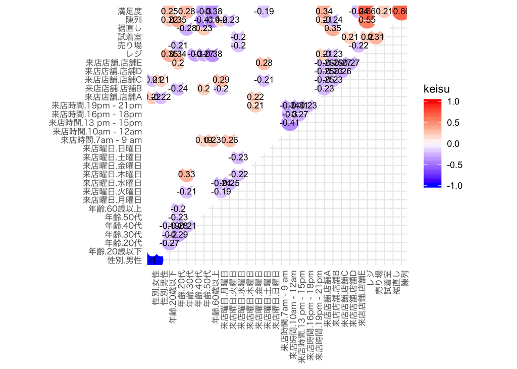

```r
ggcorrplot(corr = ud_dumm %>% scale() %>% cor(),
           p.mat = ud_dumm %>% scale() %>% cor_pmat(), # P値
           insig = "blank",# pch = 4, pch.cex = 8, sig.level = 0.05,
           show.legend = TRUE, legend.title = "keisu", #凡例
           show.diag = F, # 主対角線の表示
           sig.level = 0.05, # p値 5% で統計的有意水準
           method = "circle", # 丸表示 or square
           hc.order = F, type = "upper",
           outline.color = "white",
           lab = TRUE,  lab_size = 3, #相関係数の表示
           tl.cex = 8, tl.col = "black", tl.srt = 90) +
  theme(axis.text = element_text(family = "HiraKakuPro-W3", size = rel(0.5)))
```

## CS・顧客満足度分析

### CS分析 ポートフォリオ

### データ

#### 1. 重要度偏差値

目的変数と説明変数の相関を算出して偏差値化。正規化のタイミングはこれで正しいかあとで確認。

```r
ud.x <- cor(ud[,7:11], ud[,12]) %>% scale() * 10 + 50 #重要度 偏差値
```

#### 2. 評価偏差値

説明変数ごとの平均を算出して偏差値化。

```r
ud.y <- colMeans(ud[,7:11]) %>% scale() * 10 + 50 #評価 偏差値
```

#### 4. CS改善度

重要度と偏差値の列をバインドして列名を変更。

```r
ud.cs <- cbind(ud.x, ud.y) #列バインド
colnames(ud.cs) <- c("重要度", "評価") #列名変更
ud.cs <- data.frame(ud.cs) # data.frame化
```

CS改善度指数の算出。参考 CS改善度 https://walking-elephant.blogspot.com/2012/12/csexcel.html

```r
ud.csd <- ud.cs %>% mutate(
  距離 = sqrt((重要度 - 50)^2 + (評価 -50)^2),
  修正角度指数 = ((90 - abs(atan2(重要度 - 50, 評価 -50) * 180 / pi - 45)) / 90),
  改善度 = 距離 * 修正角度指数)
```

### CS改善度表

```r
rownames(ud.csd) <- rownames(ud.cs)
round(ud.csd[,-(3:4)], 1) %>% kable() %>% kable_styling(full_width = F, position = "left")
```

|  | 重要度 | 評価 | 改善度 |
| --- | --- | --- | --- |
| レジ | 60.5 | 54.3 | 8.4 |
| 売り場 | 44.3 | 63.2 | 3.5 |
| 試着室 | 46.8 | 46.3 | -5.1 |
| 裾直し | 38.1 | 50.3 | -5.8 |
| 陳列 | 60.3 | 36.0 | -1.7 |

### CS改善度ポートフォリオ

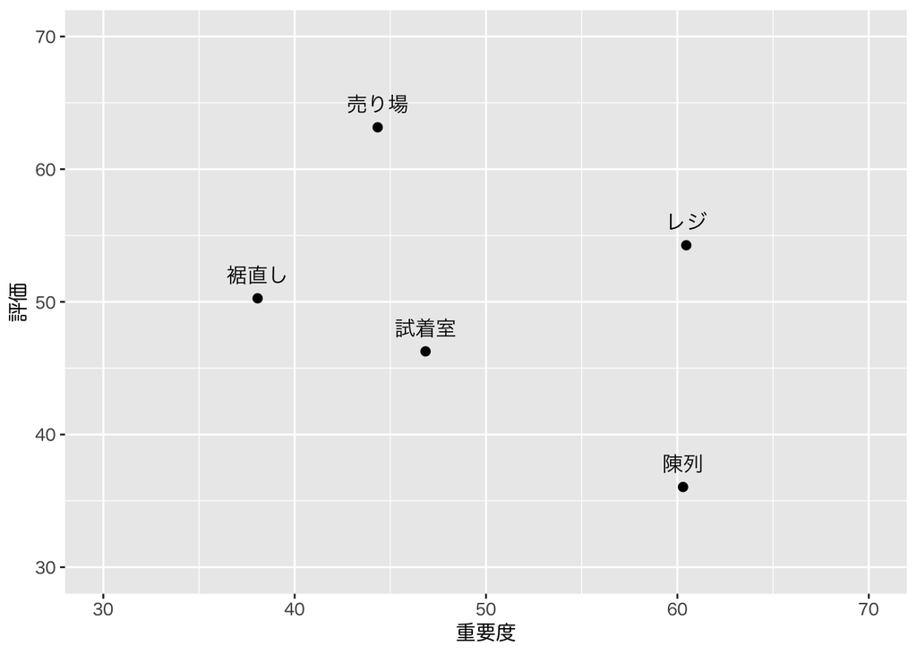

```r
ggplot(ud.cs, aes(重要度, 評価)) + geom_point(size = 2) +
  geom_text(aes(label = rownames(ud.cs)), family = "HiraKakuPro-W3", size = 4, vjust = -1) +
  ylim(30, 70) + xlim(30, 70)
```

## 4. 単純集計

### 性別

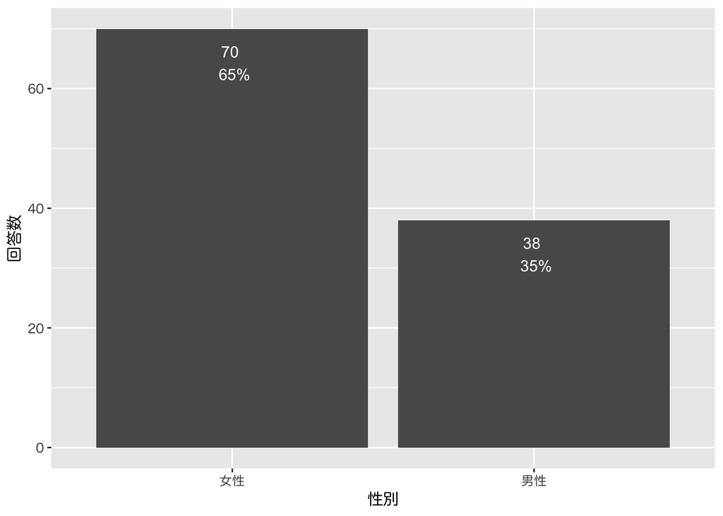

```r
ud %>% count(性別) %>% mutate(pct = percent( n / sum(n) %>% round(2), 1)) %>%
  ggplot(aes(性別, n)) + geom_col() +
  geom_text(aes(label = paste(n, "\n", pct)), color = "white", vjust = 1.5) +
  ylab("回答数")
```

```r
ud %>% count(性別) %>% mutate(pct = percent( n / sum(n) %>% round(2), 1)) %>% kable() %>% kable_styling(full_width = F, position = "left")
```

| 性別 | n | pct |
| --- | --- | --- |
| 女性 | 70 | 65% |
| 男性 | 38 | 35% |

### 年齢

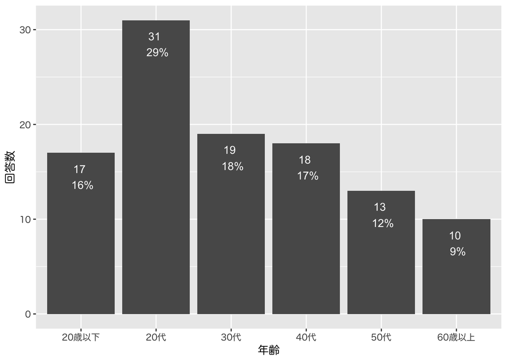

```r
ud %>% count(年齢) %>% mutate(pct = percent( n / sum(n) %>% round(2), 1)) %>%
  ggplot(aes(年齢, n)) + geom_col() +
  geom_text(aes(label = paste(n, "\n", pct)), color = "white", vjust = 1.5) +
  ylab("回答数")
```

```r
ud %>% count(年齢) %>% mutate(pct = percent( n / sum(n) %>% round(2), 1)) %>% kable() %>% kable_styling(full_width = F, position = "left")
```

| 年齢 | n | pct |
| --- | --- | --- |
| 20歳以下 | 17 | 16% |
| 20代 | 31 | 29% |
| 30代 | 19 | 18% |
| 40代 | 18 | 17% |
| 50代 | 13 | 12% |
| 60歳以上 | 10 | 9% |

### 来店曜日

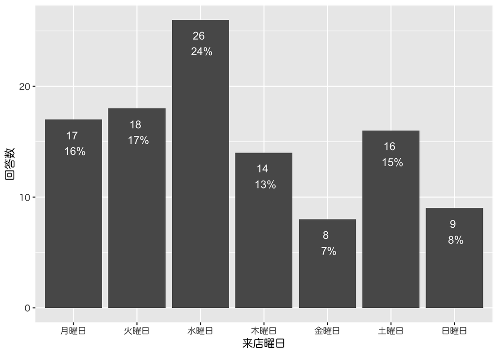

```r
ud %>% count(来店曜日) %>% mutate(pct = percent( n / sum(n) %>% round(2), 1)) %>%
  ggplot(aes(来店曜日, n)) + geom_col() +
  geom_text(aes(label = paste(n, "\n", pct)), color = "white", vjust = 1.5) +
  ylab("回答数")
```

```r
ud %>% count(来店曜日) %>% mutate(pct = percent( n / sum(n) %>% round(2), 1)) %>% kable() %>% kable_styling(full_width = F, position = "left")
```

| 来店曜日 | n | pct |
| --- | --- | --- |
| 月曜日 | 17 | 16% |
| 火曜日 | 18 | 17% |
| 水曜日 | 26 | 24% |
| 木曜日 | 14 | 13% |
| 金曜日 | 8 | 7% |
| 土曜日 | 16 | 15% |
| 日曜日 | 9 | 8% |

### 来店時間

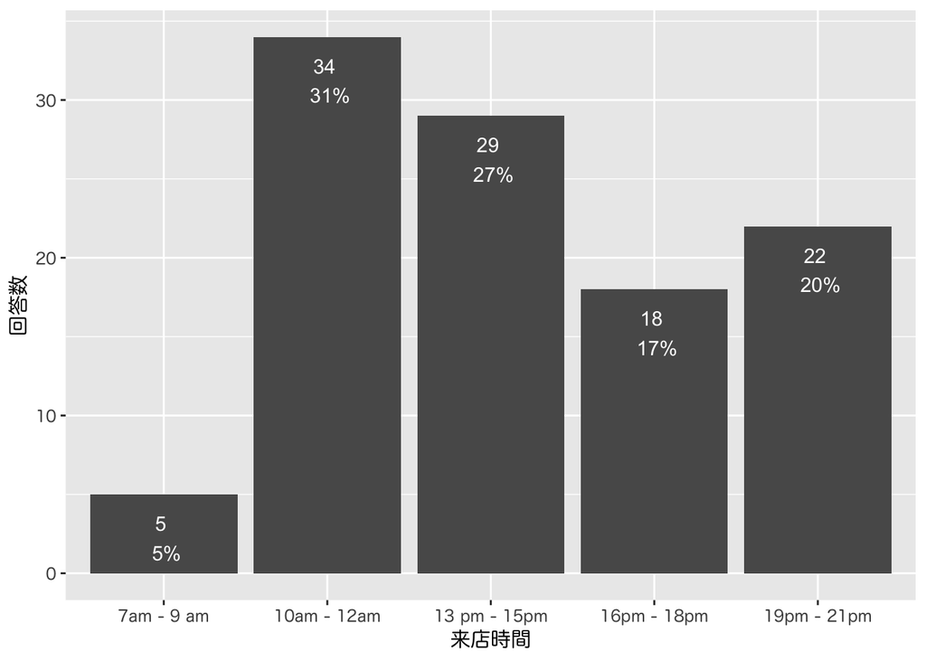

```r
ud %>% count(来店時間) %>% mutate(pct = percent( n / sum(n) %>% round(2), 1)) %>%
  ggplot(aes(来店時間, n)) + geom_col() +
  geom_text(aes(label = paste(n, "\n", pct)), color = "white", vjust = 1.5) +
  ylab("回答数")
```

```r
ud %>% count(来店時間) %>% mutate(pct = percent( n / sum(n) %>% round(2), 1)) %>% kable() %>% kable_styling(full_width = F, position = "left")
```

| 来店時間 | n | pct |
| --- | --- | --- |
| 7am - 9 am | 5 | 5% |
| 10am - 12am | 34 | 31% |
| 13 pm - 15pm | 29 | 27% |
| 16pm - 18pm | 18 | 17% |
| 19pm - 21pm | 22 | 20% |

### 来店店舗

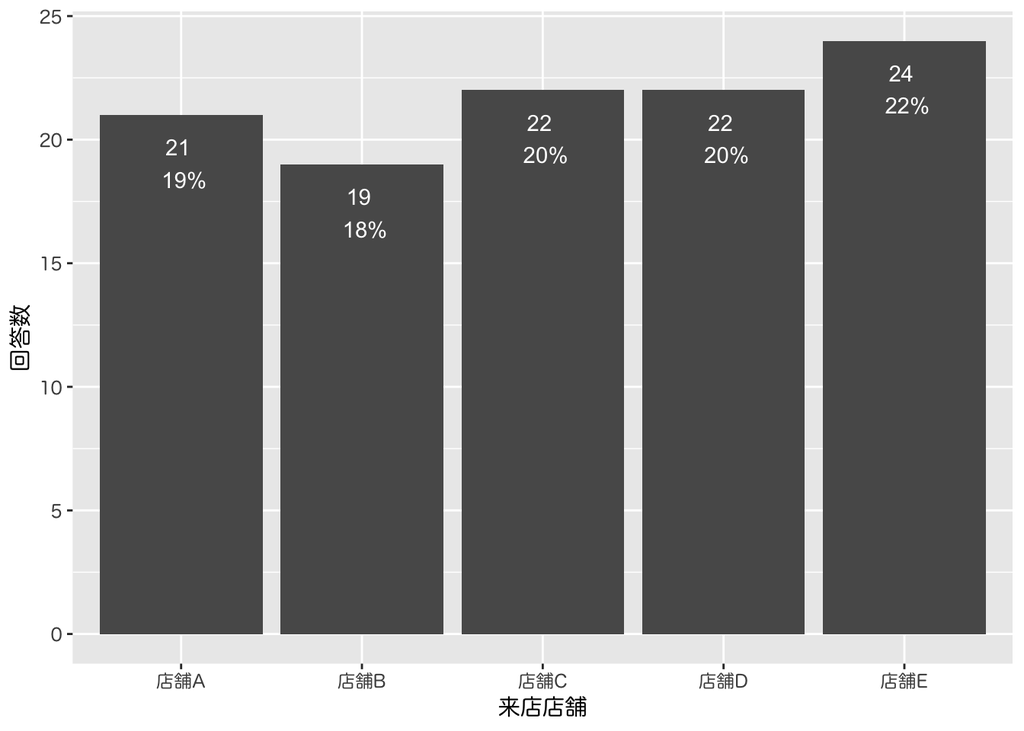

```r
ud %>% count(来店店舗) %>% mutate(pct = percent( n / sum(n) %>% round(2), 1)) %>%
  ggplot(aes(来店店舗, n)) + geom_col() +
  geom_text(aes(label = paste(n, "\n", pct)), color = "white", vjust = 1.5) +
  ylab("回答数")
```

```r
ud %>% count(来店店舗) %>% mutate(pct = percent( n / sum(n) %>% round(2), 1)) %>% kable() %>% kable_styling(full_width = F, position = "left")
```

| 来店店舗 | n | pct |
| --- | --- | --- |
| 店舗A | 21 | 19% |
| 店舗B | 19 | 18% |
| 店舗C | 22 | 20% |
| 店舗D | 22 | 20% |
| 店舗E | 24 | 22% |

### レジ

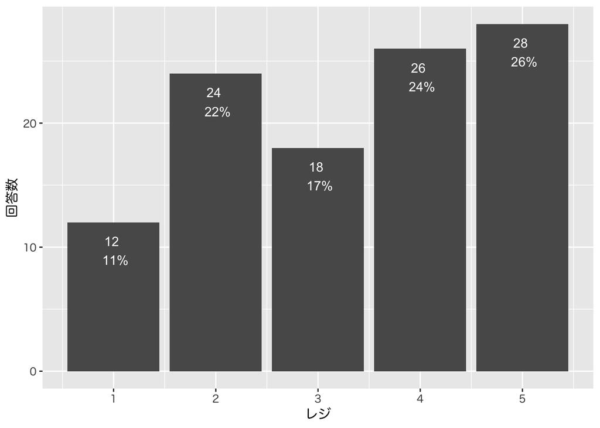

```r
ud %>% count(レジ) %>% mutate(pct = percent( n / sum(n) %>% round(2), 1)) %>%
  ggplot(aes(レジ, n)) + geom_col() +
  geom_text(aes(label = paste(n, "\n", pct)), color = "white", vjust = 1.5) +
  ylab("回答数")
```

```r
ud %>% count(レジ) %>% mutate(pct = percent( n / sum(n) %>% round(2), 1)) %>% kable() %>% kable_styling(full_width = F, position = "left")
```

| レジ | n | pct |
| --- | --- | --- |
| 1 | 12 | 11% |
| 2 | 24 | 22% |
| 3 | 18 | 17% |
| 4 | 26 | 24% |
| 5 | 28 | 26% |

### 売り場

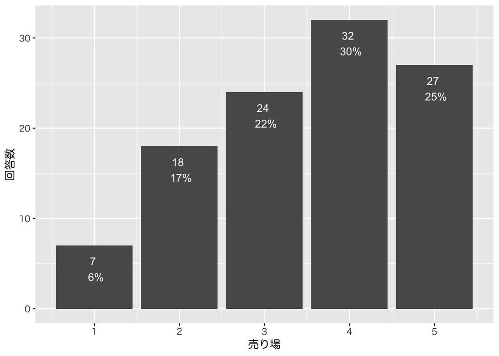

```r
ud %>% count(売り場) %>% mutate(pct = percent( n / sum(n) %>% round(2), 1)) %>%
  ggplot(aes(売り場, n)) + geom_col() +
  geom_text(aes(label = paste(n, "\n", pct)), color = "white", vjust = 1.5) +
  ylab("回答数")
```

```r
ud %>% count(売り場) %>% mutate(pct = percent( n / sum(n) %>% round(2), 1)) %>% kable() %>% kable_styling(full_width = F, position = "left")
```

| 売り場 | n | pct |
| --- | --- | --- |
| 1 | 7 | 6% |
| 2 | 18 | 17% |
| 3 | 24 | 22% |
| 4 | 32 | 30% |
| 5 | 27 | 25% |

### 試着室

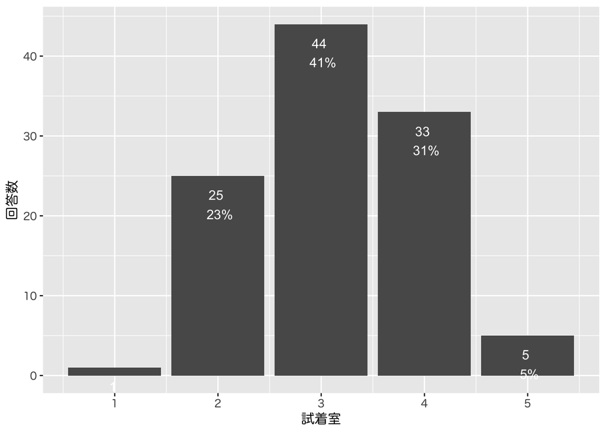

```r
ud %>% count(試着室) %>% mutate(pct = percent( n / sum(n) %>% round(2), 1)) %>%
  ggplot(aes(試着室, n)) + geom_col() +
  geom_text(aes(label = paste(n, "\n", pct)), color = "white", vjust = 1.5) +
  ylab("回答数")
```

```r
ud %>% count(試着室) %>% mutate(pct = percent( n / sum(n) %>% round(2), 1)) %>% kable() %>% kable_styling(full_width = F, position = "left")
```

| 試着室 | n | pct |
| --- | --- | --- |
| 1 | 1 | 1% |
| 2 | 25 | 23% |
| 3 | 44 | 41% |
| 4 | 33 | 31% |
| 5 | 5 | 5% |

### 裾直し

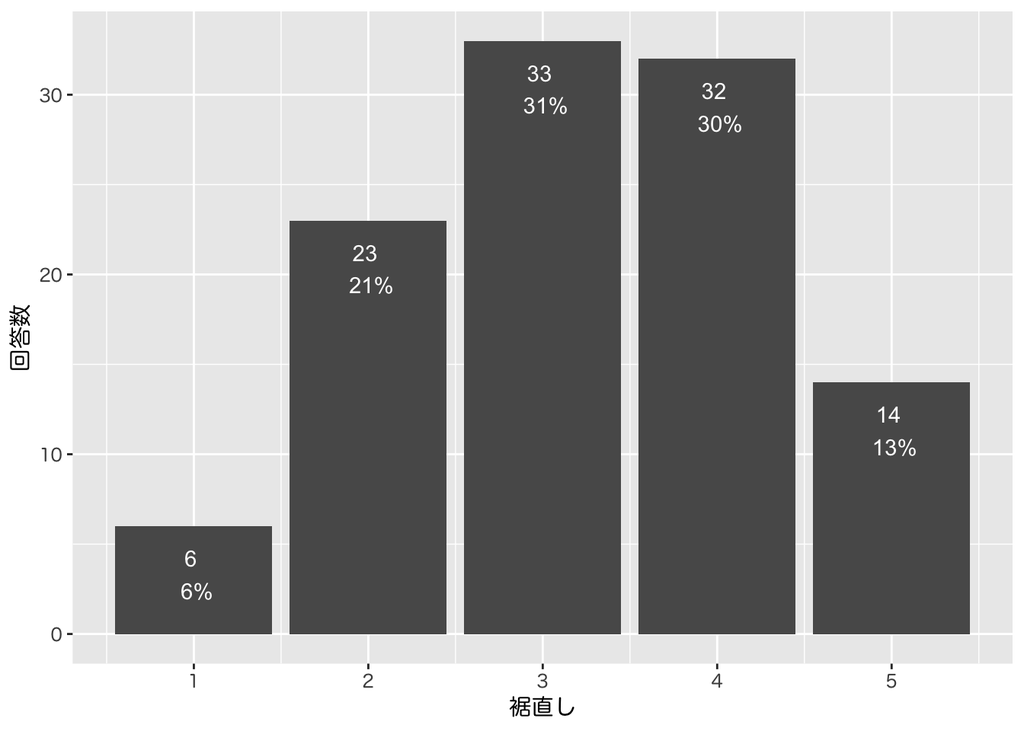

```r
ud %>% count(裾直し) %>% mutate(pct = percent( n / sum(n) %>% round(2), 1)) %>%
  ggplot(aes(裾直し, n)) + geom_col() +
  geom_text(aes(label = paste(n, "\n", pct)), color = "white", vjust = 1.5) +
  ylab("回答数")
```

```r
ud %>% count(裾直し) %>% mutate(pct = percent( n / sum(n) %>% round(2), 1)) %>% kable() %>% kable_styling(full_width = F, position = "left")
```

| 裾直し | n | pct |
| --- | --- | --- |
| 1 | 6 | 6% |
| 2 | 23 | 21% |
| 3 | 33 | 31% |
| 4 | 32 | 30% |
| 5 | 14 | 13% |

### 陳列

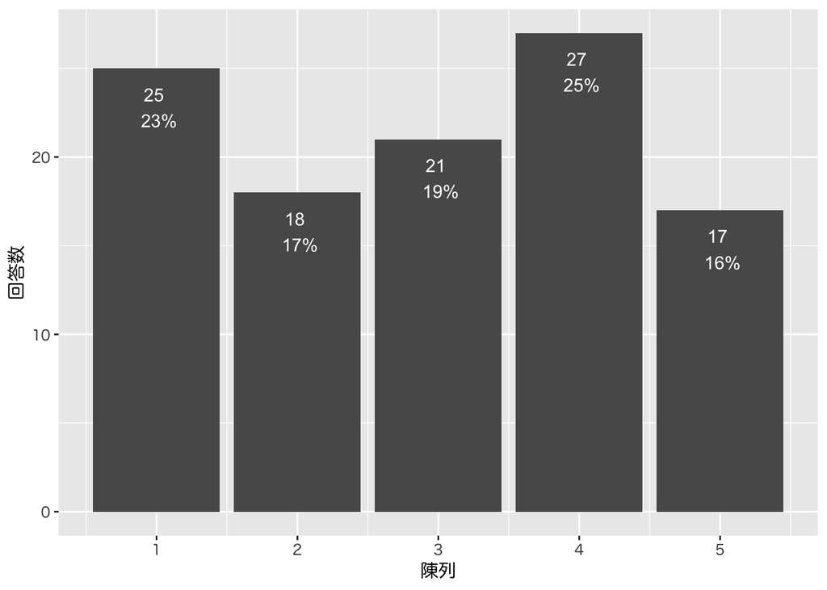

```r
ud %>% count(陳列) %>% mutate(pct = percent( n / sum(n) %>% round(2), 1)) %>%
  ggplot(aes(陳列, n)) + geom_col() +
  geom_text(aes(label = paste(n, "\n", pct)), color = "white", vjust = 1.5) +
  ylab("回答数")
```

```r
ud %>% count(陳列) %>% mutate(pct = percent( n / sum(n) %>% round(2), 1)) %>% kable() %>% kable_styling(full_width = F, position = "left")
```

| 陳列 | n | pct |
| --- | --- | --- |
| 1 | 25 | 23% |
| 2 | 18 | 17% |
| 3 | 21 | 19% |
| 4 | 27 | 25% |
| 5 | 17 | 16% |

## 回帰分析(検討中)

```r
lm(満足度~., ud_dumm) %>% summary
```

```
##
## Call:
## lm(formula = 満足度 ~ ., data = ud_dumm)
##
## Residuals:
##      Min       1Q   Median       3Q      Max
## -1.66674 -0.54252  0.00613  0.47970  1.92667
##
## Coefficients: (5 not defined because of singularities)
##                         Estimate Std. Error t value Pr(>|t|)
## (Intercept)             -0.73790    0.69380  -1.064 0.290650
## 性別.女性               -0.38700    0.19498  -1.985 0.050512 .
## 性別.男性                     NA         NA      NA       NA
## 年齢.20歳以下            0.79052    0.52491   1.506 0.135909
## 年齢.20代                0.52277    0.49059   1.066 0.289739
## 年齢.30代                0.98190    0.46552   2.109 0.037972 *
## 年齢.40代                0.57659    0.40641   1.419 0.159761
## 年齢.50代                0.25726    0.38881   0.662 0.510051
## 年齢.60歳以上                 NA         NA      NA       NA
## 来店曜日.月曜日          0.10349    0.40745   0.254 0.800133
## 来店曜日.火曜日         -0.09611    0.39250  -0.245 0.807167
## 来店曜日.水曜日          0.06246    0.36668   0.170 0.865167
## 来店曜日.木曜日         -0.09971    0.43710  -0.228 0.820128
## 来店曜日.金曜日          0.26520    0.45557   0.582 0.562082
## 来店曜日.土曜日         -0.21141    0.37744  -0.560 0.576932
## 来店曜日.日曜日               NA         NA      NA       NA
## `来店時間.7am - 9 am`   -0.30805    0.51092  -0.603 0.548215
## `来店時間.10am - 12am`   0.06471    0.26116   0.248 0.804909
## `来店時間.13 pm - 15pm`  0.06846    0.28079   0.244 0.807987
## `来店時間.16pm - 18pm`  -0.06390    0.32038  -0.199 0.842410
## `来店時間.19pm - 21pm`        NA         NA      NA       NA
## 来店店舗.店舗A           0.89726    0.30689   2.924 0.004469 **
## 来店店舗.店舗B           1.01847    0.30975   3.288 0.001487 **
## 来店店舗.店舗C           0.14262    0.31604   0.451 0.652980
## 来店店舗.店舗D          -0.03102    0.29930  -0.104 0.917717
## 来店店舗.店舗E                NA         NA      NA       NA
## レジ                     0.38673    0.09750   3.966 0.000155 ***
## 売り場                   0.09920    0.08082   1.227 0.223176
## 試着室                   0.23577    0.11562   2.039 0.044664 *
## 裾直し                   0.03486    0.08866   0.393 0.695197
## 陳列                     0.32286    0.09335   3.458 0.000864 ***
## ---
## Signif. codes:  0 '***' 0.001 '**' 0.01 '*' 0.05 '.' 0.1 ' ' 1
##
## Residual standard error: 0.8557 on 82 degrees of freedom
## Multiple R-squared:  0.727,  Adjusted R-squared:  0.6437
## F-statistic: 8.733 on 25 and 82 DF,  p-value: 2.795e-14
```